# Introduction to fairGATE

# 1. Introduction

The **fairGATE** package provides a complete pipeline for training and evaluating a Gated Neural Network (GNN) designed to mitigate demographic bias in predictive modelling. The package implements a fairness-aware GNN that uses a custom loss function to enforce the *Equalized Odds* fairness criterion by minimising the variance in True Positive and False Positive Rates across subgroups.

# 2. The fairGATE Workflow

The package is built around a logical sequence of functions:

- `prepare_data()`: Cleans and prepares the input data.
- `train_gnn()`: Trains the Gated Neural Network.
- `analyse_gnn_results()`: Conducts performance and gate analysis.
- `analyse_experts()`: Performs analysis of expert specialisation.
- `plot_sankey()`: Visualises the model’s patient routing behaviour.

## 2.1. Loading Data

First, we load the necessary libraries and the dataset.

We use a small in-package sample of the UCI Adult dataset. Outcome is **income** (1 = >50K, 0 = ≤50K); protected attribute is **sex**.

```r
library(fairGATE)
library(dplyr)
library(readxl)
library(here)
# Loading the UCI Adult Dataset

adult_data <- read.csv(here("data", "adult_ready.csv"), row.names = NULL)

adult <- adult_data %>%
  mutate(
    across(where(is.character), ~ trimws(.x)),
    income = as.integer(income)
  )
```

## 2.2. Step 1: Prepare the Data

We use `prepare_data()` to process the raw data for the Male/Female analysis.

```r
# Dropping unwanted cols (i.e. numeric cols and those with high multicolinearity)
cols_to_drop <- c("subjectid", "Row.names")

#  Ensure to perform other preprocessing steps such as one-hot endoing etc

# Fully prepared data goes here

prepared <- fairGATE::prepare_data(
  data          = adult,
  outcome_var   = "income",
  group_var     = "sex",
  cols_to_remove= cols_to_drop
)
```

```
#> Auto-generated group_mappings: Male, Female
```

## 2.3. Train a small demo model

```r
# Train a small Gated Neural Network
trained_model <- fairGATE::train_gnn(
  prepared_data = prepared,
  run_tuning    = FALSE,     # skip tuning for speed
  best_params   = list(
    lr = 0.01,
    hidden_dim = 16,
    dropout_rate = 0.1,
    lambda = 0.0,
    temperature = 1.0
  ),
  num_repeats   = 2,         # very short repeated split
  epochs        = 20,        # fast CRAN-safe runtime
  verbose       = FALSE
)
```

## 2.4. Step 3: Analyse Basic Performance and Gates

With the results loaded, we run `analyse_gnn_results()` to generate all the standard performance plots and gate analyses.

```r
# Run basic analysis
basic_analyses <- analyse_gnn_results(
  gnn_results = trained_model,
  prepared_data = prepared
)

# --- View all plots from the basic analysis ---
cat("## ROC Curve\n")
```

```
#> ## ROC Curve
```

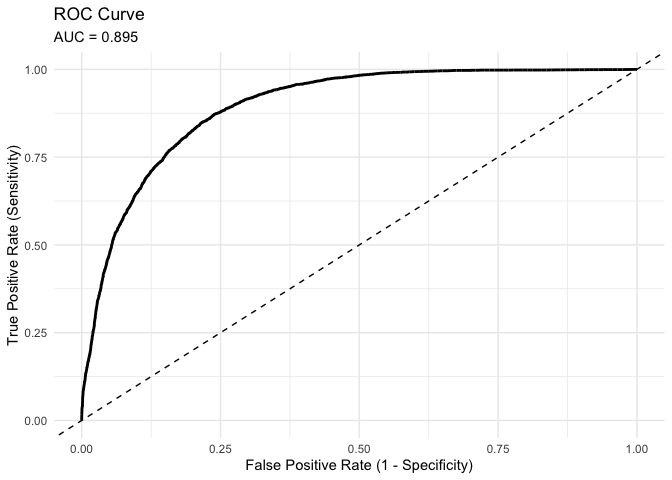

```r
print(basic_analyses$roc_plot)
```

```r
cat("\n## Calibration Plot\n")
```

```
#>
#> ## Calibration Plot
```

[figure not shown]

```r
print(basic_analyses$calibration_plot)
```

```r
cat("\n## Gate Weight Distribution\n")
```

```
#>
#> ## Gate Weight Distribution
```

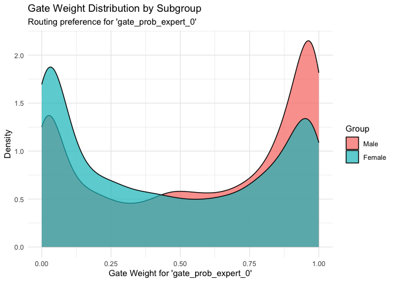

```r
print(basic_analyses$gate_density_plot)
```

```r
cat("\n## Gate Entropy Distribution\n")
```

```
#>
#> ## Gate Entropy Distribution
```

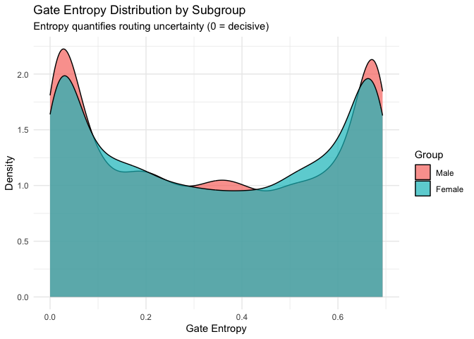

```r
print(basic_analyses$entropy_density_plot)
```

## 2.5. Step 4: Analyse Expert Specialisation

Now, we use `analyse_experts()` to investigate how the different expert networks have specialised their learning.

The `analyse_experts()` function summarises expert weights per subgroup, compares mean importance across groups, and produces difference or multi-group plots.

```r
exp_res <- analyse_experts(
  gnn_results     = trained_model,   # from train_gnn()
  prepared_data   = prepared,        # from prepare_data()
  top_n_features  = 15,              # number of top features to visualise
  verbose         = TRUE
)
```

```
#> Starting Expert Feature Weight Analysis...
#> Using group_mappings retrieved from prepared_data attributes.
#> Feature importance summaries computed.
```

```r
# View the main objects returned
names(exp_res)
```

[output not shown]

```r
# View first few feature importances
head(exp_res$means_by_group_wide)
```

```
#> # A tibble: 6 × 3
#>   feature          Male Female
#>   <chr>           <dbl>  <dbl>
#> 1 age            0.141  0.143
#> 2 capital_gain   0.175  0.154
#> 3 capital_loss   0.114  0.100
#> 4 education_10th 0.0894 0.0861
#> 5 education_11th 0.106  0.0988
#> 6 education_12th 0.0632 0.0718
```

```r
# Example: view one pairwise difference table
names(exp_res$pairwise_differences)
```

[output not shown]

```r
head(exp_res$pairwise_differences[[1]])
```

```
#> # A tibble: 6 × 4
#>   feature                        Male Female difference
#>   <chr>                         <dbl>  <dbl>      <dbl>
#> 1 native_country_Mexico        0.0499 0.0883     0.0384
#> 2 marital_status_Separated     0.0494 0.0877     0.0383
#> 3 relationship_Other.relative  0.0638 0.100      0.0367
#> 4 occupation_Machine.op.inspct 0.0957 0.0628    -0.0329
#> 5 hours_per_week               0.155  0.129     -0.0261
#> 6 education_7th.8th            0.0732 0.0993     0.0260
```

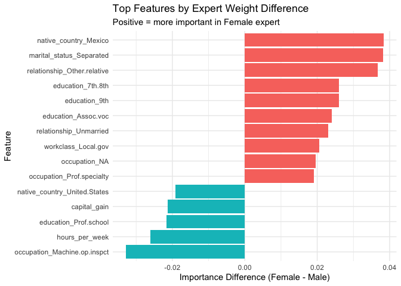

```r
# Visualise feature specialisation
if (!is.null(exp_res$difference_plot)) print(exp_res$difference_plot)
```

```r
if (!is.null(exp_res$multi_group_plot)) print(exp_res$multi_group_plot)
```

## 2.6. Step 5: Visualise Patient Routing with a Sankey Plot

We can use `plot_sankey()` to create the key visualisation from the research paper, showing how patients are routed through the model.

The Sankey shows how patients flow from actual subgroup -> assigned expert. It auto-derives subgroup labels from `prepared` and subject IDs from `trained_model`.

```r
# Generate and print the Sankey plot
p <- plot_sankey(
  prepared_data  = prepared,       # from prepare_data()
  gnn_results    = trained_model,  # from train_gnn()
  expert_results = exp_res,        # from analyse_experts()
  verbose        = TRUE
)
```

```
#> Sankey: deriving assigned expert per subject...
#> Sankey: using 2-axis (group -> expert).
```

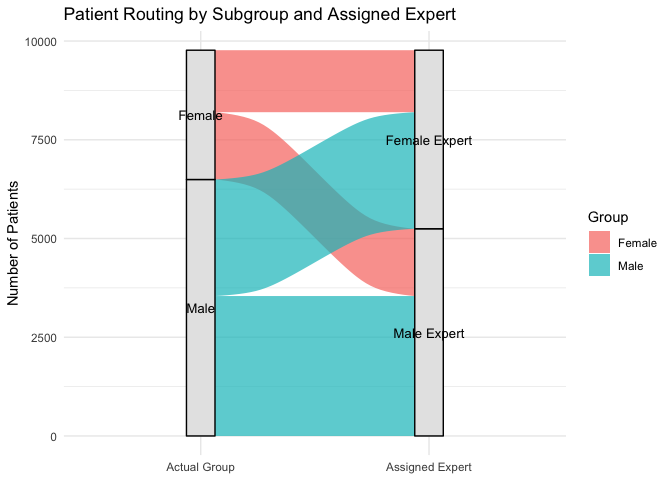

```r
print(p)
```

## 2.7. (Optional) Export data for Fairness 360 or external fairness analysis

```r
export_f360_csv(
  gnn_results       = trained_model,   # from train_gnn()
  prepared_data     = prepared,        # from prepare_data()
  path              = "outputs/fairness360_input.csv",
  include_gate_cols = TRUE,            # include expert routing probabilities
  threshold         = 0.5,             # classification threshold for binary outcome
  verbose           = TRUE
)
```